# Lecture #24: Base Graphics I

#### Useful Color Palettes

This is some material pasted from a blog [The Paul Tol 21-color salute](http://www.r-bloggers.com/the-paul-tol-21-color-salute/) with useful color palettes.

You may or may not know that PerformanceAnalytics contains a number of specific color schemes designed for charting data in R (they aren’t documented well, but they show up in some of the chart examples). I’ve been collecting color palates for years in search of good combinations of attractiveness, relative weight, and distinctiveness, helped along the way by great sites like ColorBrewer and packages like RColorBrewer. I’ve assembled palettes that work for specific purposes, such as the color-focus palates (e.g., redfocus is red plus a series of dark to light gray colors). Others, such as rich#equal, provide a palette for displaying data that all deserve equal treatment in the chart. Each of these palettes have been designed to create readable, comparable line and bar graphs with specific objectives outlined before each category below.

I use this approach rather than generating schemes on the fly for two reasons: it creates fewer dependencies on libraries that don’t need to be called dynamically; and to guarantee the color used for the n-th column of data.

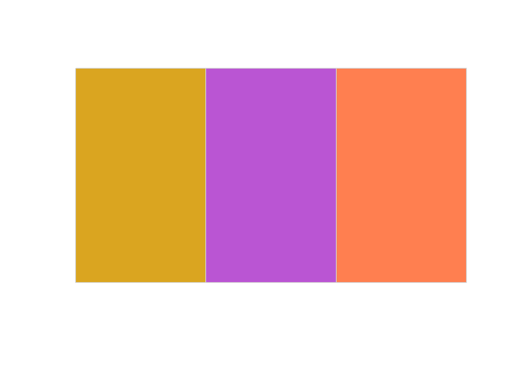

```r
# Function for plotting colors side-by-side
# Written by Adam Zeileis in the color.space package
pal <- function(col=c("goldenrod","mediumorchid","coral"), border = "light gray", ...){
  n <- length(col)
  plot(0, 0, type="n", xlim = c(0, 1), ylim = c(0, 1),
       axes = FALSE, xlab = "", ylab = "", ...)
  rect(0:(n-1)/n, 0, 1:n/n, 1, col = col, border = border)
  }
pal()
```

**Focus Palettes** The Focus palettes are colorsets designed to provide focus to the data graphed as the first element. These palettes are best used when there is clearly an important data set for the viewer to focus on, with the remaining data being secondary, tertiary, etc. Later elements are shown in diminishing values of gray. These were generated with RColorBrewer, using the 8 level “grays” palette and replacing the darkest gray with the focus color.

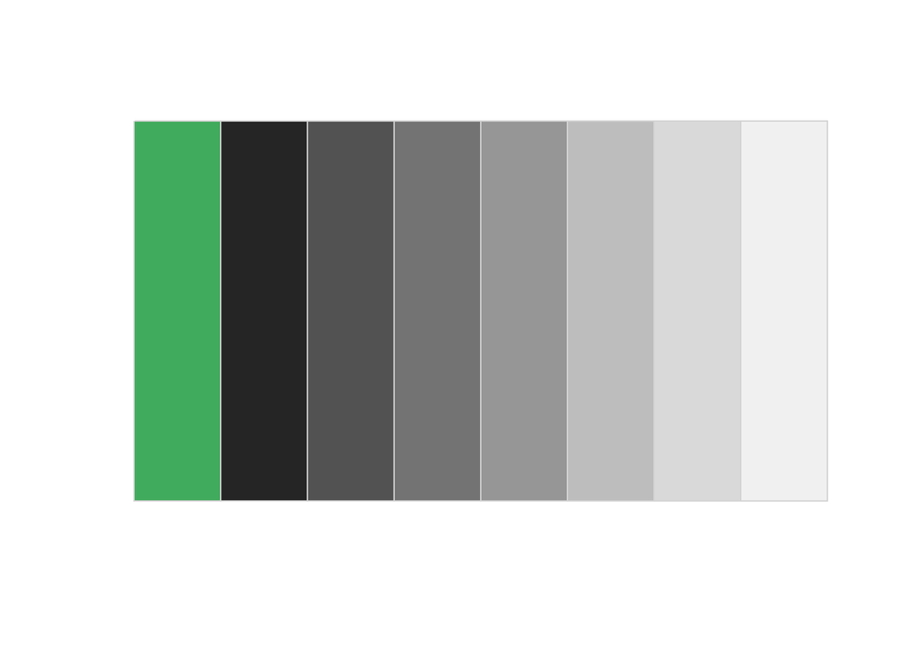

```r
# FOCUS PALETTES
# Red as highlight
redfocus = c("#CB181D", "#252525", "#525252", "#737373", "#969696", "#BDBDBD", "#D9D9D9", "#F0F0F0")

# Green as highlight
greenfocus = c("#41AB5D", "#252525", "#525252", "#737373", "#969696", "#BDBDBD", "#D9D9D9", "#F0F0F0")

# Blue as highlight
bluefocus = c("#0033FF", "#252525", "#525252", "#737373", "#969696", "#BDBDBD", "#D9D9D9", "#F0F0F0")

pal(greenfocus)
```

**Equal Weights Palettes** Equal Weight palettes colorsets are fine for when all of the data should be distinguishable and carry similar weight, such as on a line graph or bar plot. The different numbers in the name indicate the number of colors generated (six colors is probably the maximum for a completely readable linegraph).

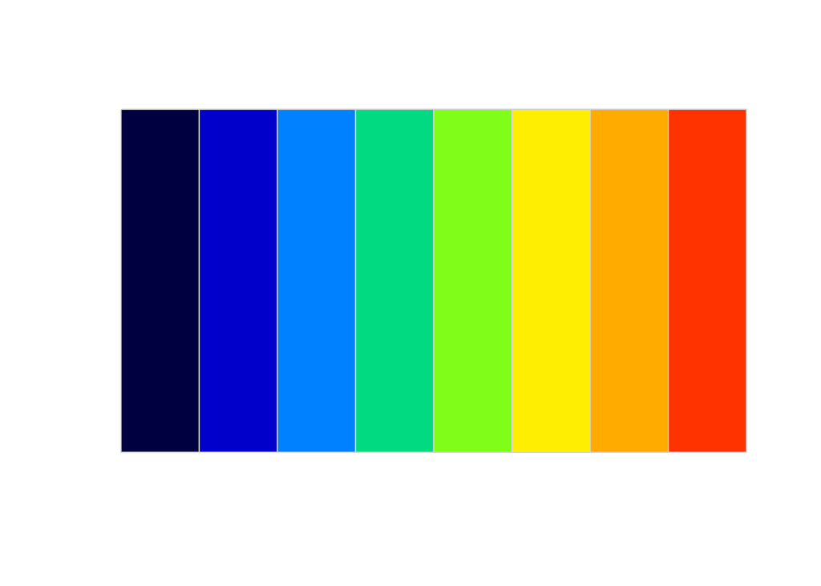

```r
# EQUAL WEIGHT
# Generated with rainbow(12, s = 0.6, v = 0.75)
rainbow12equal = c("#BF4D4D", "#BF864D", "#BFBF4D", "#86BF4D", "#4DBF4D", "#4DBF86", "#4DBFBF", "#4D86BF", "#4D4DBF", "#864DBF", "#BF4DBF", "#BF4D86")
rainbow10equal = c("#BF4D4D", "#BF914D", "#A8BF4D", "#63BF4D", "#4DBF7A", "#4DBFBF", "#4D7ABF", "#634DBF", "#A84DBF", "#BF4D91")
rainbow8equal = c("#BF4D4D", "#BFA34D", "#86BF4D", "#4DBF69", "#4DBFBF", "#4D69BF", "#864DBF", "#BF4DA3")
rainbow6equal = c("#BF4D4D", "#BFBF4D", "#4DBF4D", "#4DBFBF", "#4D4DBF", "#BF4DBF")

# Generated with package "gplots" function rich.colors(12)
rich12equal = c("#000040", "#000093", "#0020E9", "#0076FF", "#00B8C2", "#04E466", "#49FB25", "#E7FD09", "#FEEA02", "#FFC200", "#FF8500", "#FF3300")
rich10equal = c("#000041", "#0000A9", "#0049FF", "#00A4DE", "#03E070", "#5DFC21", "#F6F905", "#FFD701", "#FF9500", "#FF3300")
rich8equal = c("#000041", "#0000CB", "#0081FF", "#02DA81", "#80FE1A", "#FDEE02", "#FFAB00", "#FF3300")
rich6equal = c("#000043", "#0033FF", "#01CCA4", "#BAFF12", "#FFCC00", "#FF3300")

# Generated with package "fields" function tim.colors(12), which is said to emulate the default matlab colorset
tim12equal = c("#00008F", "#0000EA", "#0047FF", "#00A2FF", "#00FEFF", "#5AFFA5", "#B5FF4A", "#FFED00", "#FF9200", "#FF3700", "#DB0000", "#800000")
tim10equal = c("#00008F", "#0000FF", "#0070FF", "#00DFFF", "#50FFAF", "#BFFF40", "#FFCF00", "#FF6000", "#EF0000", "#800000")
tim8equal = c("#00008F", "#0020FF", "#00AFFF", "#40FFBF", "#CFFF30", "#FF9F00", "#FF1000", "#800000")
tim6equal = c("#00008F", "#005AFF", "#23FFDC", "#ECFF13", "#FF4A00", "#800000")

# Generated with sort(brewer.pal(8,"Dark2")) #Dark2, Set2
dark8equal = c("#1B9E77", "#666666", "#66A61E", "#7570B3", "#A6761D", "#D95F02", "#E6AB02", "#E7298A")
dark6equal = c("#1B9E77", "#66A61E", "#7570B3", "#D95F02", "#E6AB02", "#E7298A")
set8equal = c("#66C2A5", "#8DA0CB", "#A6D854", "#B3B3B3", "#E5C494", "#E78AC3", "#FC8D62", "#FFD92F")
set6equal = c("#66C2A5", "#8DA0CB", "#A6D854", "#E78AC3", "#FC8D62", "#FFD92F")

pal(rich8equal)
```

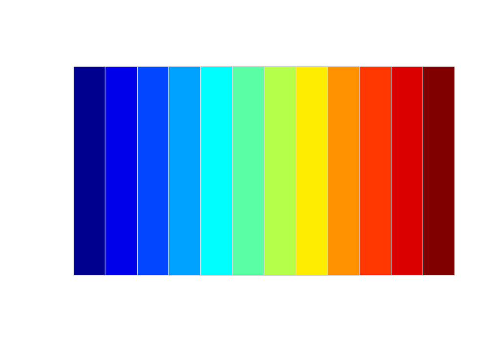

```r
pal(tim12equal)
```

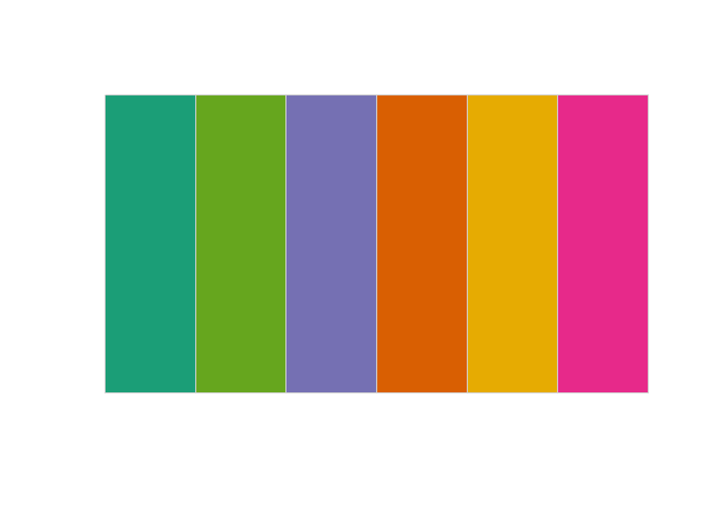

```r
pal(dark6equal)
```

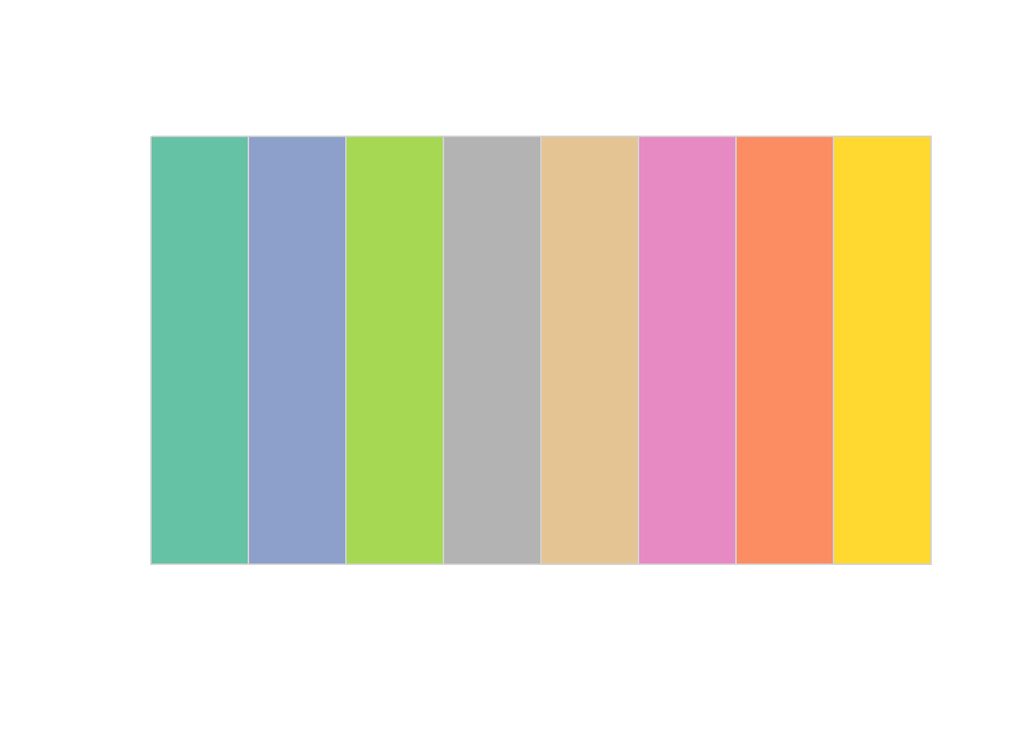

```r
pal(set8equal)
```

**Monochrome Palettes** The last category are Monochrome palettes, which I like in both stacked bar plots and with a few lines.

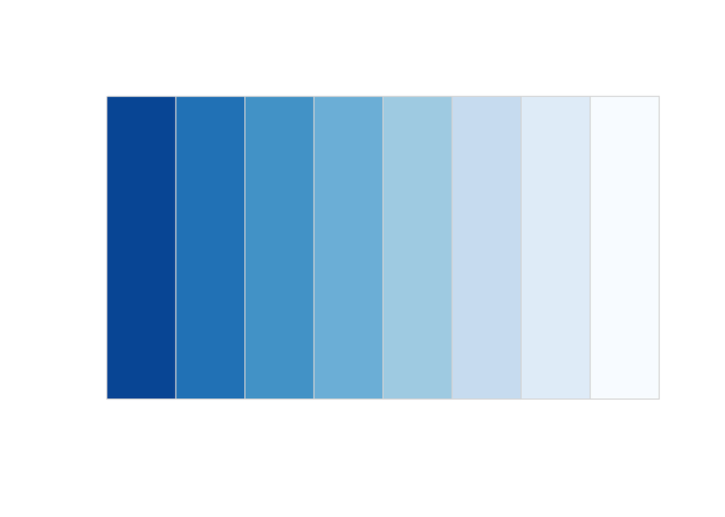

```r
# MONOCHROME PALETTES
# sort(brewer.pal(8,"Greens"))
redmono = c("#99000D", "#CB181D", "#EF3B2C", "#FB6A4A", "#FC9272", "#FCBBA1", "#FEE0D2", "#FFF5F0")
greenmono = c("#005A32", "#238B45", "#41AB5D", "#74C476", "#A1D99B", "#C7E9C0", "#E5F5E0", "#F7FCF5")
bluemono = c("#084594", "#2171B5", "#4292C6", "#6BAED6", "#9ECAE1", "#C6DBEF", "#DEEBF7", "#F7FBFF")
grey8mono = c("#000000","#252525", "#525252", "#737373", "#969696", "#BDBDBD", "#D9D9D9", "#F0F0F0")
grey6mono = c("#242424", "#494949", "#6D6D6D", "#929292", "#B6B6B6", "#DBDBDB")

pal(bluemono)
```

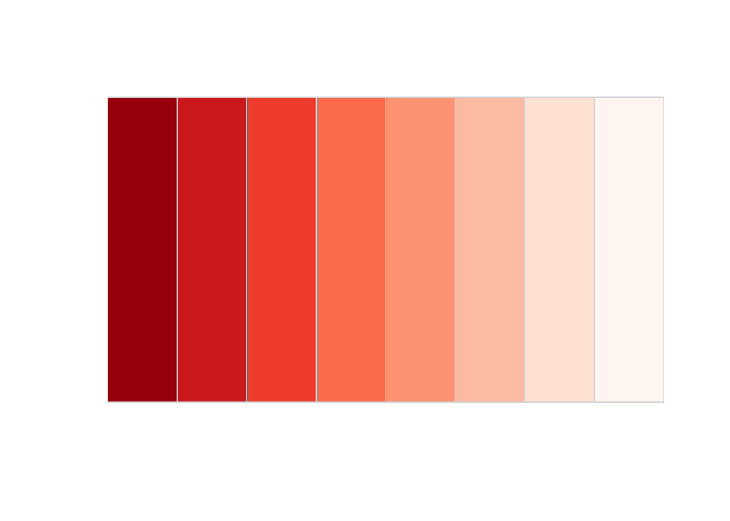

```r
pal(redmono)
```

A while ago I decided that none of these schemes was quite discernable enough for what I needed to do. I frequently display line graphs that require the reader to differentiate among the colors, and sometimes I need more differentiable colors than is advisable. I did a bit of hunting around and came across [Paul Tol’s SRON Technical Note](http://www.sron.nl/~pault/colourschemes.pdf) and have since been using his color schemes for qualitative data, which are nicely distinctive and come with more combinations than many of the best ColorBrewer sets.

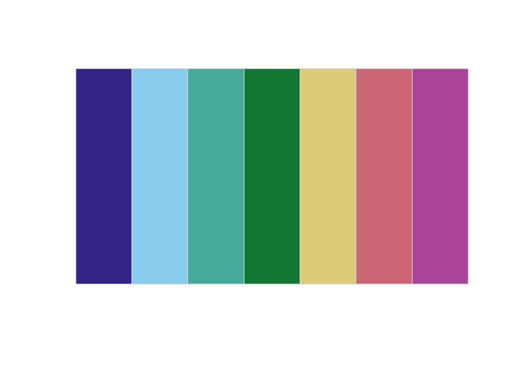

```r
# Qualitative color schemes by Paul Tol
 tol1qualitative=c("#4477AA")
 tol2qualitative=c("#4477AA", "#CC6677")
 tol3qualitative=c("#4477AA", "#DDCC77", "#CC6677")
 tol4qualitative=c("#4477AA", "#117733", "#DDCC77", "#CC6677")
 tol5qualitative=c("#332288", "#88CCEE", "#117733", "#DDCC77", "#CC6677")
 tol6qualitative=c("#332288", "#88CCEE", "#117733", "#DDCC77", "#CC6677","#AA4499")
 tol7qualitative=c("#332288", "#88CCEE", "#44AA99", "#117733", "#DDCC77", "#CC6677","#AA4499")
 tol8qualitative=c("#332288", "#88CCEE", "#44AA99", "#117733", "#999933", "#DDCC77", "#CC6677","#AA4499")
 tol9qualitative=c("#332288", "#88CCEE", "#44AA99", "#117733", "#999933", "#DDCC77", "#CC6677", "#882255", "#AA4499")
 tol10qualitative=c("#332288", "#88CCEE", "#44AA99", "#117733", "#999933", "#DDCC77", "#661100", "#CC6677", "#882255", "#AA4499")
 tol11qualitative=c("#332288", "#6699CC", "#88CCEE", "#44AA99", "#117733", "#999933", "#DDCC77", "#661100", "#CC6677", "#882255", "#AA4499")
 tol12qualitative=c("#332288", "#6699CC", "#88CCEE", "#44AA99", "#117733", "#999933", "#DDCC77", "#661100", "#CC6677", "#AA4466", "#882255", "#AA4499")

pal(tol7qualitative)
```

A recent update to Paul’s technical paper adds a new banded rainbow scheme, and several have a large number of steps. He notes that when you’re using them you’re better off picking a scheme that matches the number of colors needed, rather than using only a few colors from a larger scheme.

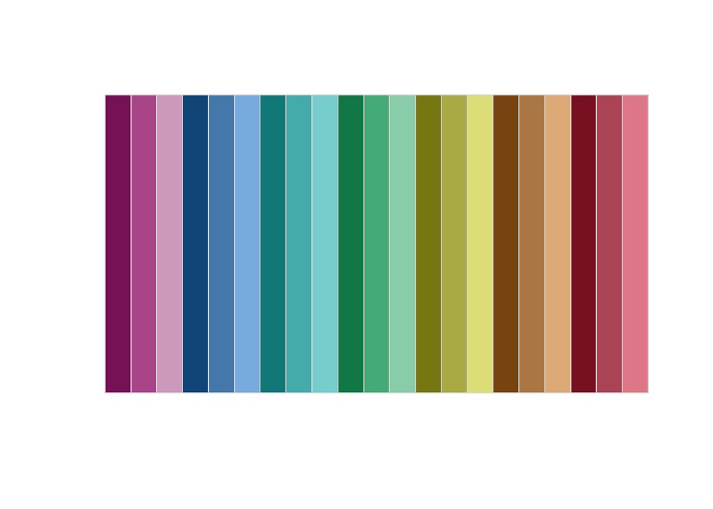

```r
tol14rainbow=c("#882E72", "#B178A6", "#D6C1DE", "#1965B0", "#5289C7", "#7BAFDE", "#4EB265", "#90C987", "#CAE0AB", "#F7EE55", "#F6C141", "#F1932D", "#E8601C", "#DC050C")
tol15rainbow=c("#114477", "#4477AA", "#77AADD", "#117755", "#44AA88", "#99CCBB", "#777711", "#AAAA44", "#DDDD77", "#771111", "#AA4444", "#DD7777", "#771144", "#AA4477", "#DD77AA")
tol18rainbow=c("#771155", "#AA4488", "#CC99BB", "#114477", "#4477AA", "#77AADD", "#117777", "#44AAAA", "#77CCCC", "#777711", "#AAAA44", "#DDDD77", "#774411", "#AA7744", "#DDAA77", "#771122", "#AA4455", "#DD7788")
# ...and finally, the Paul Tol 21-color salute
tol21rainbow= c("#771155", "#AA4488", "#CC99BB", "#114477", "#4477AA", "#77AADD", "#117777", "#44AAAA", "#77CCCC", "#117744", "#44AA77", "#88CCAA", "#777711", "#AAAA44", "#DDDD77", "#774411", "#AA7744", "#DDAA77", "#771122", "#AA4455", "#DD7788")

pal(tol21rainbow)
```

Ok, I admit that 21 colors is pushing it when it comes to discernability on the screen or page. But sometimes there are too many lines anyway and you need to try to show them all. So this is a nice set to pull from your back pocket before reverting to a continuous series.

I’d be curious if you’ve found a color scheme you like – if so, add it to the comments…

**Palette From Comments**

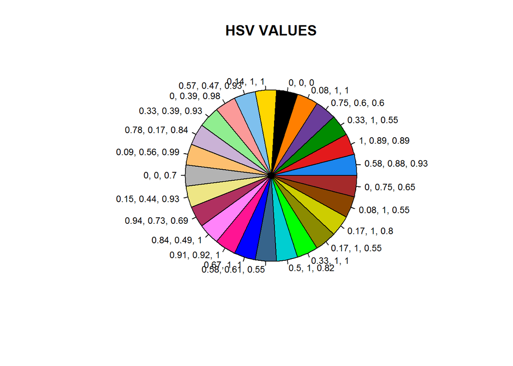

```r
# Kevin Wright says
mycols=c("dodgerblue2", "#E31A1C", "green4", "#6A3D9A", "#FF7F00", "black",
"gold1", "skyblue2", "#FB9A99", "palegreen2", "#CAB2D6", "#FDBF6F",
"gray70", "khaki2", "maroon", "orchid1", "deeppink1", "blue1",
"steelblue4", "darkturquoise", "green1", "yellow4", "yellow3",
"darkorange4", "brown")

ones <- rep(1, length=length(mycols))
# Get hsv for labels
names(ones) <- apply(round(rgb2hsv(col2rgb(c(mycols))),2), 2,
function(x) {paste(x, collapse=", ")})
pie(ones, col=mycols, cex=.76, main = "HSV VALUES")
```

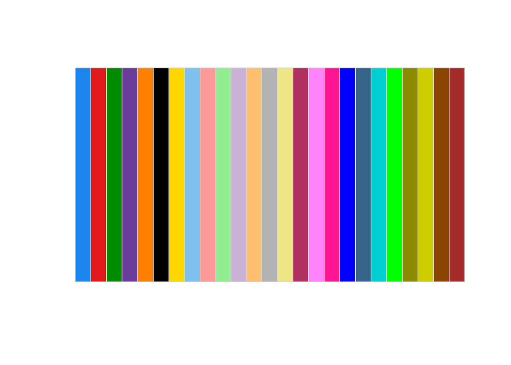

```r
pal(mycols)
```

### Legends

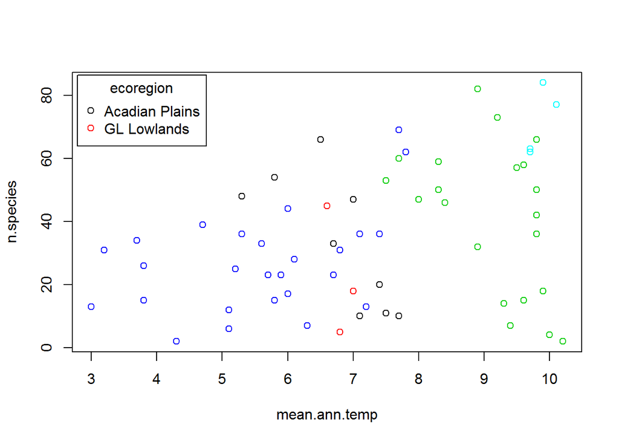

```r
######################################################################
# plot with colors as groups
par(opar)
plot(mean.ann.temp,n.species,col=as.integer(as.factor(ecoregion)))
legend("topleft", inset=0.01, title="ecoregion",
       c("Acadian Plains","GL Lowlands"),
       pch=1,col=palette()[c(1,2)])
```

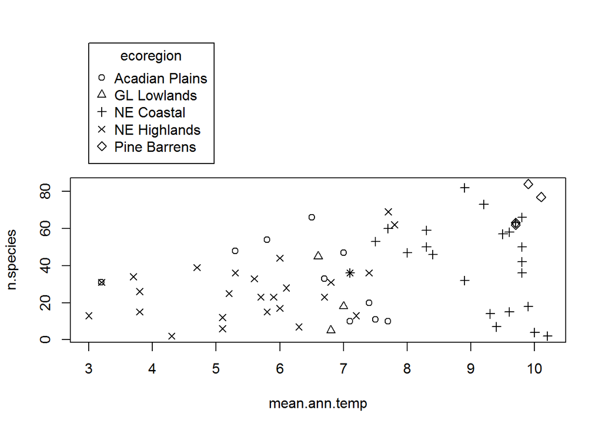

```r
# plot with symbols as groups
par(xpd=NA) # suppress clipping
par(fig=c(0,1,0,0.75)) # move figure down in plot space

plot(mean.ann.temp,n.species,pch=as.integer(as.factor(ecoregion)))
legend(3,160, title="ecoregion",
       c("Acadian Plains","GL Lowlands",
         "NE Coastal", "NE Highlands", "Pine Barrens"),
       pch=1:5)
```

```r
par(opar)
########################################################################
```

### Inset Figures

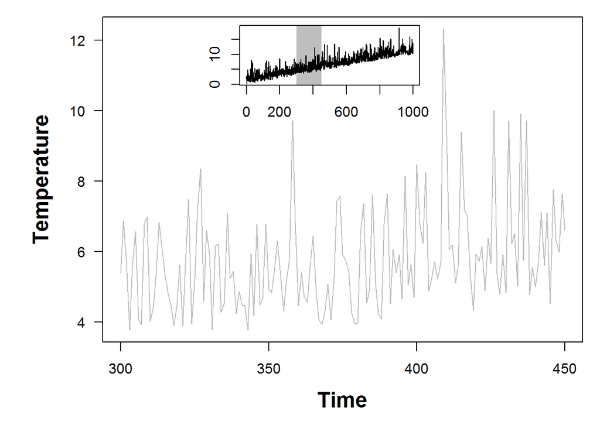

```r
par(opar)
set.seed(102)

####################################################
# create a stochastic increasing time series

x <- 1:1000
y <- rgamma(1000,shape=2,scale=1) + 0.01*x

###################################################
# select a time slice for plotting
slice <- 300:450

# create the main graph

par(mar=c(5,6,1,1))
plot(x[slice],y[slice],xlim=range(slice),col="gray",type="l",
     xlab="Time",ylab="Temperature",
     font.lab=2,cex.lab=1.5,las=1,ylim=range(y[slice]))

##################################################################
#add par commands to strip margins, overplot, and place the inset

par(new=TRUE) # overlay existing plot
par(mar=c(0,0,0,0)) # strip out the margins for the inset plot
par(fig=c(0.4,0.7,0.80,0.94)) # fig shrinks and places relative to figure region

#################################################################
# separately create the inset graph

plot(x,y,type="l",ann=FALSE)
rect(slice[1],-1,slice[length(slice)],1000,col="gray",border=NA)
box()
lines(x,y)
```

```r
#########################################
par(opar)
```

### Miscellaneous Functions

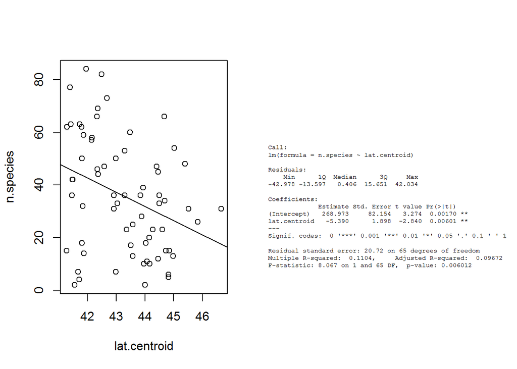

```r
par(opar)
##############################################################
# Add formatted text to a plot
library(gplots)
par(mfrow=c(1,2))
plot(lat.centroid,n.species)
reg.model <- lm(n.species~lat.centroid)
abline(reg.model)

textplot(capture.output(summary(reg.model)))
```

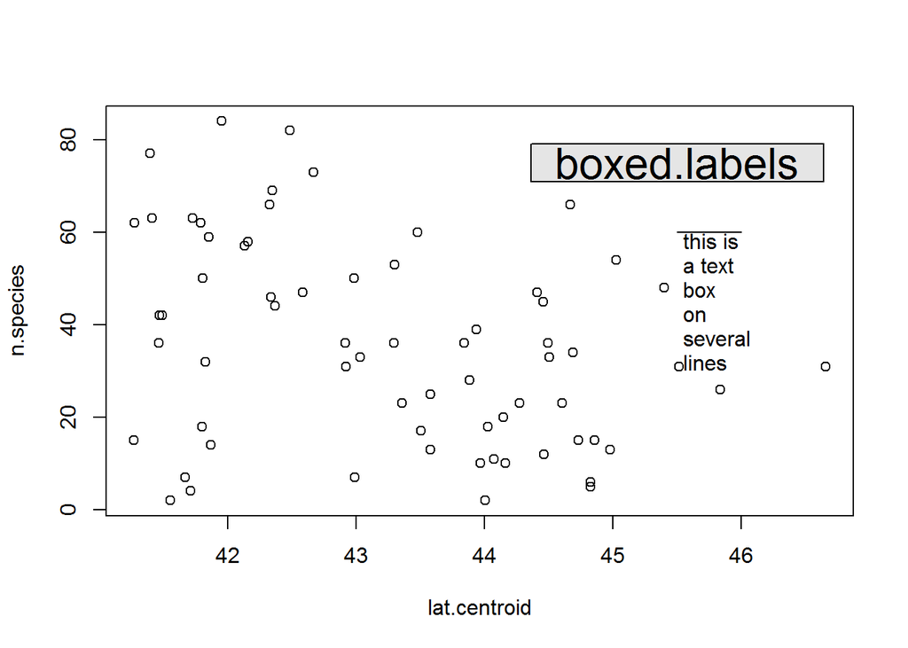

```
## [1] 28.47151
```

```r
par(opar)
##############################################################
# Add a boxed label to a plot
library(plotrix)
plot(lat.centroid,n.species)

# give x, y positions
boxed.labels(45.5,75,"boxed.labels",bg="gray90",cex=2)
###############################################################
# Add a text box to a plot
library(plotrix)


#give c(xmin,xmax), y top; # lines determined by amount of text
textbox(c(45.5,46.0),60,"this is a text box on several lines")
```

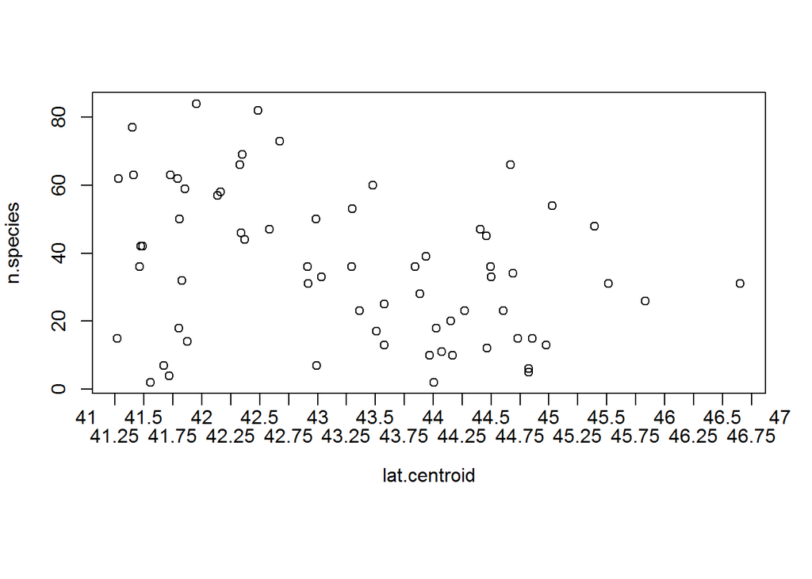

```r
###############################################################
# stack the labels if they are too crowded
library(plotrix)
par(mar=c(8,4,4,2))
plot(lat.centroid,n.species,axes=FALSE)
axis(1,labels=FALSE)
axis(2)
box()
my.labs <-round(seq(41,47,by=0.25),3)
staxlab(1,at=my.labs) #add srt=45 to rotate
```

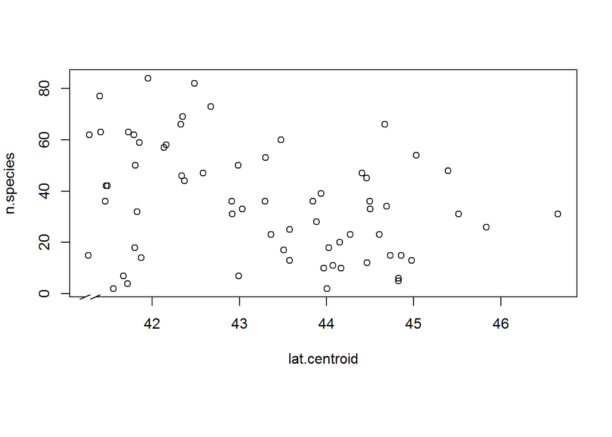

```r
################################################################
# add an axis break
library(plotrix)
plot(lat.centroid,n.species)
axis.break(1)
```

```r
par(opar)
```

### Graphics For Proteomics & Big Data

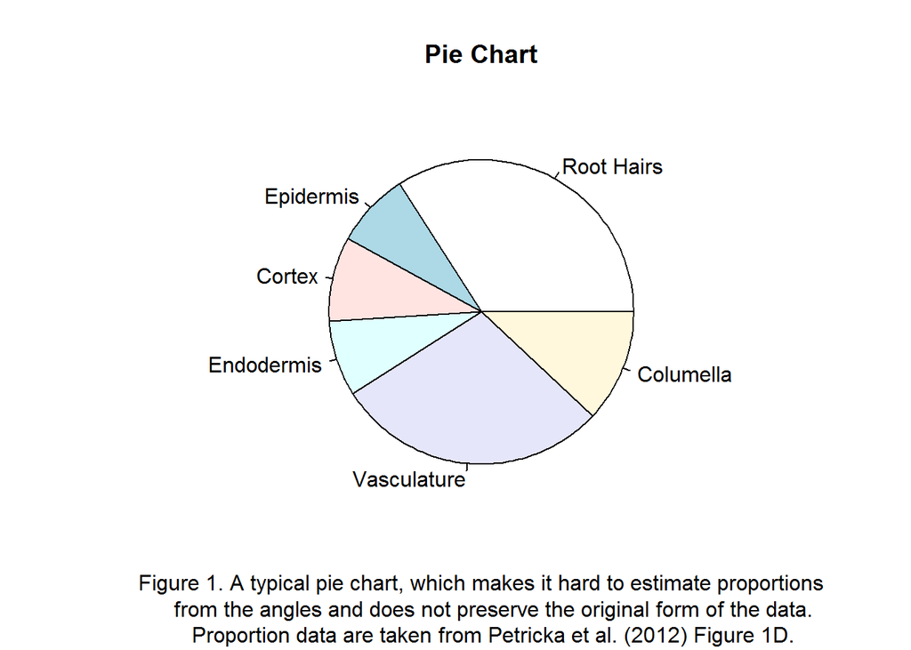

```r
################################################
# Figure 1. standard pie chart
# data from Petricka et al. 2012 Fig 1D

Arab.labels <- c("Root Hairs", "Epidermis","Cortex",
                 "Endodermis","Vasculature", "Columella")
Protein.per <- c(34,8,9,8,29,12)
pie(Protein.per, labels=Arab.labels,main="Pie Chart",
    sub="Figure 1. A typical pie chart, which makes it hard to estimate proportions
    from the angles and does not preserve the original form of the data.
    Proportion data are taken from Petricka et al. (2012) Figure 1D.")
```

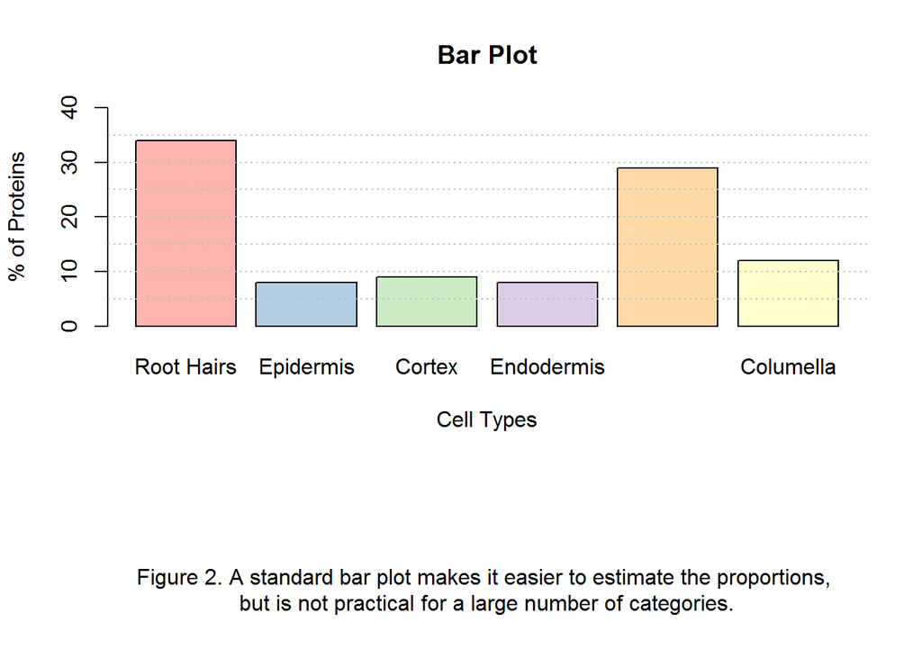

```r
###############################################
# Figure 2. replotted as a bar chart
library(RColorBrewer)
Brew.cols <- brewer.pal(6,"Pastel1")
par(fig=c(0,1,0.3,1))
barplot(Protein.per,names.arg=Arab.labels,ylim=c(0,40),col=Brew.cols,
        ylab="% of Proteins",xlab="Cell Types", main = "Bar Plot")
mtext("Figure 2. A standard bar plot makes it easier to estimate the proportions,
but is not practical for a large number of categories.", side= 1,line=10)
grid(nx=0,ny=8,col="gray")
```

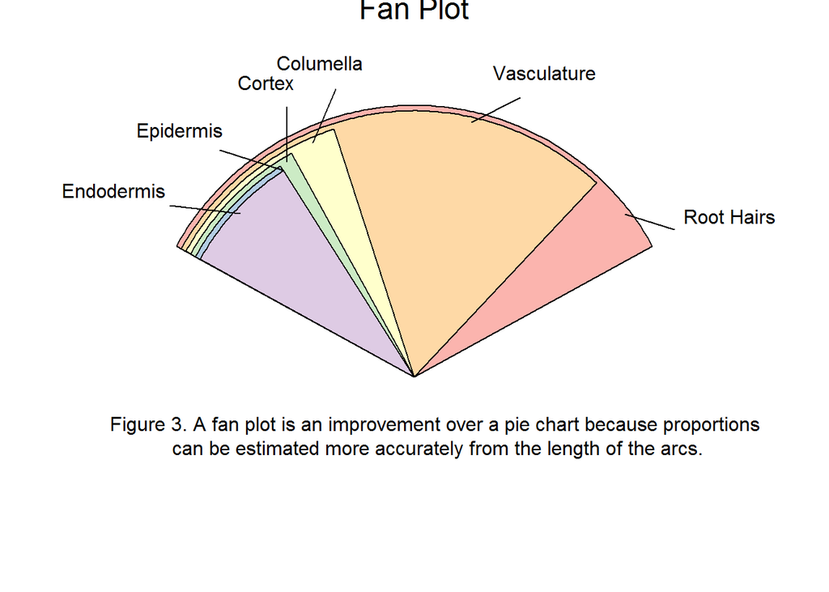

```r
par(opar)
##################################################################
# Figure 3. improved with a fan chart with RColorBrewer palette
library(plotrix)
library(RColorBrewer)
Brew.cols <- brewer.pal(6,"Pastel1")
par(fig=c(0,1,0.3,1))
fan.plot(Protein.per, labels = Arab.labels, col=Brew.cols, main="Fan Plot")
par(new=TRUE)
par(fig=c(0,1,0.3,1))
plot(Protein.per,type="n",font.sub=1,axes=FALSE, ann=FALSE)
mtext("Figure 3. A fan plot is an improvement over a pie chart because proportions
can be estimated more accurately from the length of the arcs.", side= 1,line=6)
```

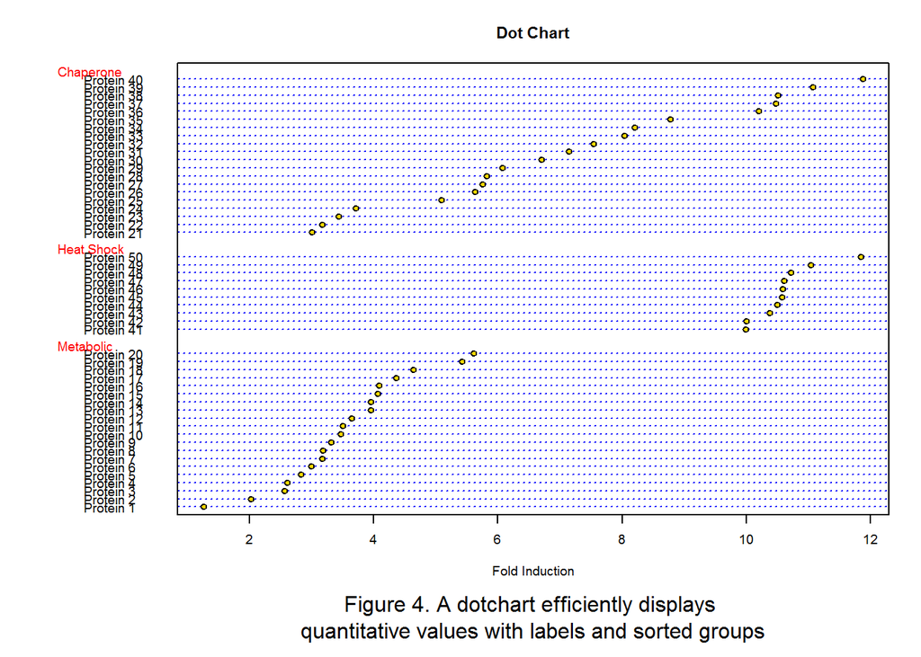

```r
par(opar)
########################################################
#Figure 4. dotchart for long lists of elements
par(mar=c(9,4,4,2))
Protein.list = paste("Protein",1:50,"     ")
Express1 <- sort(runif(20,1,6))
Express2 <- sort(runif(20,3,12))
Express3 <- sort(runif(10,9,12))
Proteins <- c(Express1,Express2,Express3)
Grps <- factor(c(rep("Metabolic",20),rep("Chaperone",20),rep("Heat Shock",10)))
dotchart(Proteins,labels=Protein.list,,groups=Grps,xlab="Fold Induction",
         gcolor="red",pch=21,bg="gold",lcol="blue",cex=0.6, main="Dot Chart")
mtext("Figure 4. A dotchart efficiently displays
quantitative values with labels and sorted groups",side=1,line=7)
```

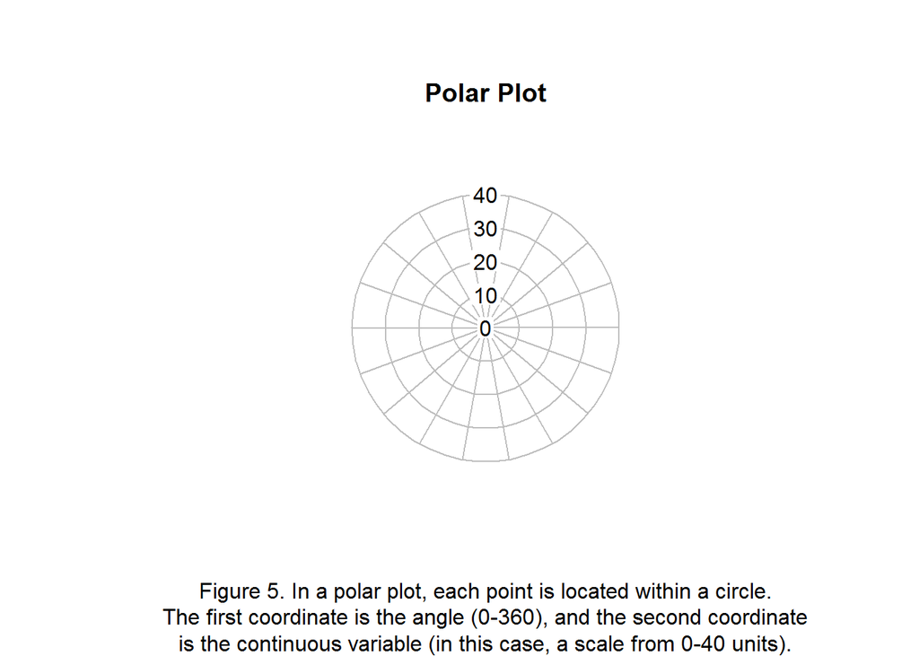

```r
par(opar)
##################################################
# Figure 5. plot showing polar coordinates
library(plotrix)
par(fig=c(0,1,0.2,1))
polar.plot(lengths=0,polar.pos=seq(135,240,length=6),
           main="Polar Plot",lwd=10,line.col=NA,
           radial.lim=c(0,40),start=0,rp.type="r",
           labels="",
           show.grid.labels=3,mar=c(2,4,7,2))

mtext("Figure 5. In a polar plot, each point is located within a circle.
The first coordinate is the angle (0-360), and the second coordinate
is the continuous variable (in this case, a scale from 0-40 units).", side= 1,line=6)
```

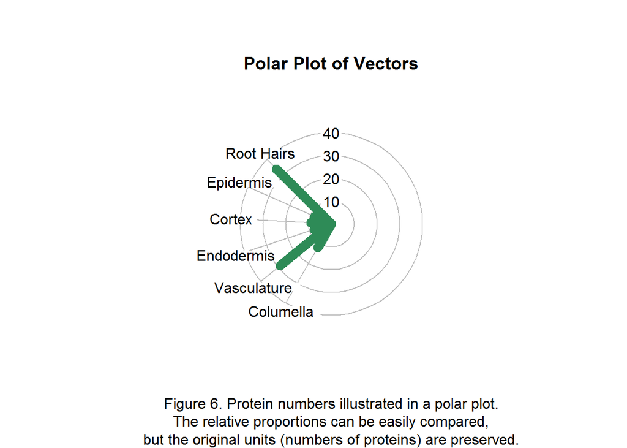

```r
par(opar)
########################################
# Figure 6. Simple plot of protein numbers
library(plotrix)
par(fig=c(0,1,0.2,1))
polar.plot(lengths=Protein.per,polar.pos=seq(135,240,length=6),
           main="Polar Plot of Vectors",lwd=10,line.col=NA,
           radial.lim=c(0,40),start=0,rp.type="r",
           labels=Arab.labels,label.pos=seq(135,240,length=6),
           show.grid.labels=3,mar=c(2,4,7,2))
polar.plot(lengths=Protein.per,polar.pos=seq(135,240,length=6),
           add=TRUE, main="",lwd=10,line.col="seagreen",
           radial.lim=c(0,40),start=0,rp.type="r",
           labels=Arab.labels,label.pos=seq(135,240,length=6),
           show.grid.labels=3,mar=c(2,4,7,2),show.grid=FALSE,
           show.radial.grid=FALSE)
mtext("Figure 6. Protein numbers illustrated in a polar plot.
The relative proportions can be easily compared,
but the original units (numbers of proteins) are preserved.", side= 1,line=6)
```

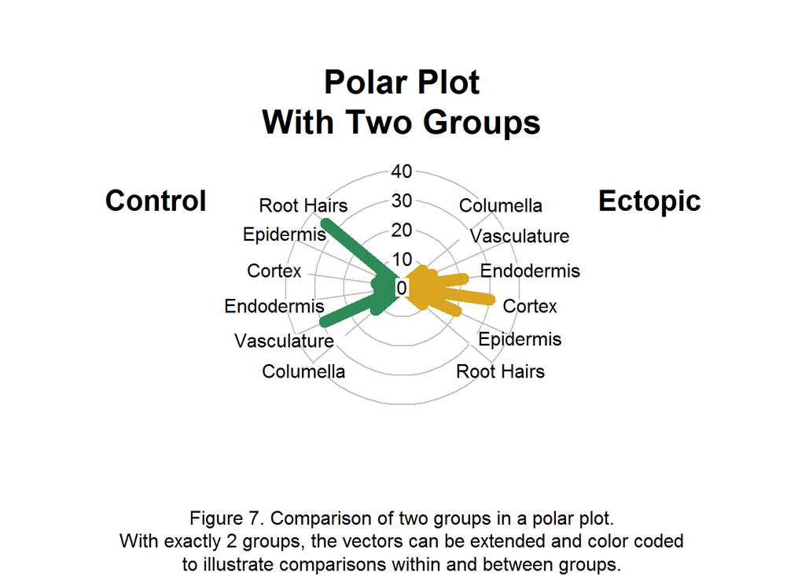

```r
par(opar)
#############################################################
# Figure 7. Now add a second set and color code for a new treatment
par(fig=c(0,1,0.2,1))
Protein2.per <- c(9,20,30,21,11,9)

polar.plot(lengths=c(Protein.per,Protein2.per),
           polar.pos=rep(seq(140,220,length=6),2)+rep(c(0,180),each=6),
           lwd=10,line.col=rep(c("seagreen","goldenrod"),each=6),
           radial.lim=c(0,40),start=0,rp.type="r",
           labels=Arab.labels,
           label.pos=rep(seq(140,220,length=6),2)+rep(c(0,180),each=6),
           show.grid.labels=3,mar=c(2,4,7,4),cex=2)

           mtext("Control",side=2,font=2,las=1,cex=1.5,line=3,at=30)
           mtext("Ectopic",side=4,font=2,las=1,cex=1.5,line=3,at=30)
           mtext("Polar Plot\nWith Two Groups",side=3,font=2,las=1,cex=1.75,line=1,
                 at=0)
mtext("Figure 7. Comparison of two groups in a polar plot.
With exactly 2 groups, the vectors can be extended and color coded
to illustrate comparisons within and between groups.", side= 1,line=6)
```

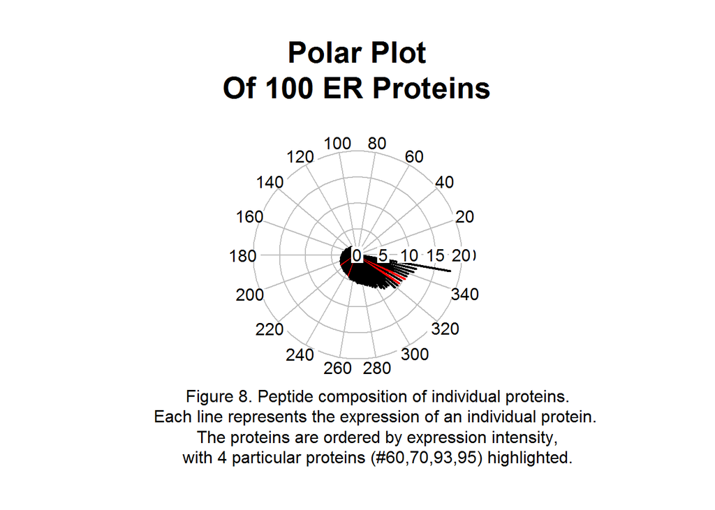

```r
par(opar)
#####################################################
# Figure 8. Create a graph for 100 proteins, with 4 proteins coded
par(fig=c(0,1,0.2,1))
Protein.col <- rep("black",100)
Protein.col[c(60, 70, 93,95)] <- "red"
Protein.express <- sort(rgamma(100,shape=1,scale=3))
polar.plot(lengths=Protein.express,
           polar.pos=seq(10,350,length=100),
           lwd=2,line.col=Protein.col,
           radial.lim=c(0,max(Protein.express)),start=0,rp.type="r",
           show.grid.labels=4,mar=c(2,4,7,4),cex=2)
mtext("Polar Plot\nOf 100 ER Proteins",side=3,font=2,las=1,cex=1.75,line=2,
      at=0)
par(opar)
mtext("Figure 8. Peptide composition of individual proteins.
Each line represents the expression of an individual protein.
The proteins are ordered by expression intensity,
with 4 particular proteins (#60,70,93,95) highlighted.", side= 1,line=2)
```

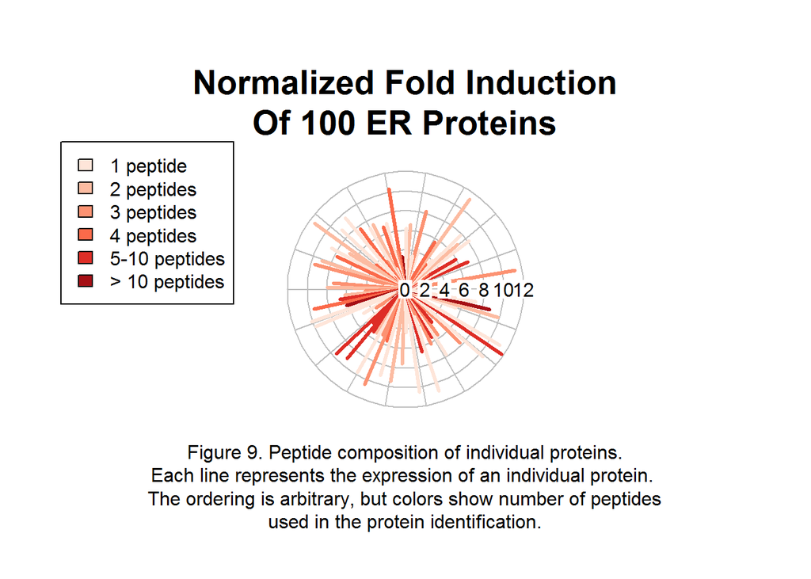

```r
par(opar)
#############################################################
# Figure 9. Create a graph for 100 proteins, with special coding for peptide number
par(fig=c(0,1,0.2,1))

library(RColorBrewer)
my.reds <- brewer.pal(6,"Reds")
red6 <- sample(my.reds,100,replace=TRUE,prob=6:1)
Protein.express <- sort(rgamma(100,shape=1,scale=3))
Protein.express <- runif(100,0,12)
polar.plot(lengths=Protein.express,
           polar.pos=seq(10,350,length=100),
           lwd=3,line.col=red6,
           radial.lim=c(0,max(Protein.express)),start=0,rp.type="r",
           labels="",
           show.grid.labels=4,mar=c(2,4,7,4),cex=2)
mtext("Normalized Fold Induction\nOf 100 ER Proteins",side=3,font=2,las=1,cex=1.75,line=1,
      at=0)
legend(-35,15,pt.cex=1.2,legend=c("1 peptide","2 peptides","3 peptides",
                       "4 peptides", "5-10 peptides","> 10 peptides"),
       fill=my.reds)
mtext("Figure 9. Peptide composition of individual proteins.
Each line represents the expression of an individual protein.
The ordering is arbitrary, but colors show number of peptides
used in the protein identification.", side= 1,line=4)
```

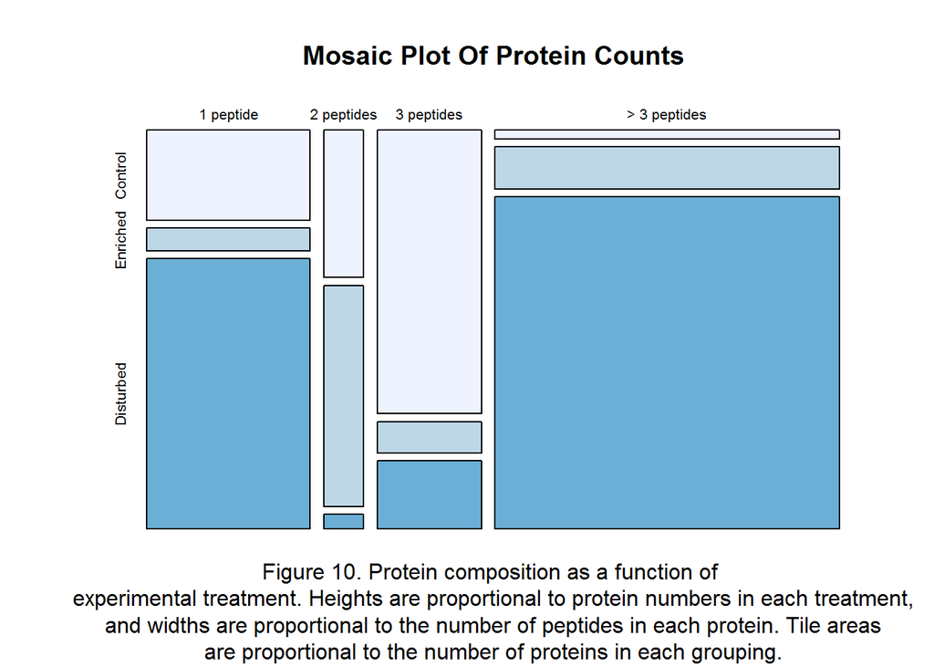

```r
par(opar)

####################################################
# Figure 10. mosaic plot for two categorical variables
library(RColorBrewer)
my.blues <- brewer.pal(4,"Blues")
Protein.counts <- matrix(c(100,25,300,40,60,4,200,22,48,20,99,777),nrow=3,
     dimnames=list(c("Control","Enriched","Disturbed"),c("1 peptide","2 peptides",
                    "3 peptides", "> 3 peptides")))
mosaicplot(t(Protein.counts),col=my.blues,main="Mosaic Plot Of Protein Counts")
mtext("Figure 10. Protein composition as a function of
experimental treatment. Heights are proportional to protein numbers in each treatment,
and widths are proportional to the number of peptides in each protein. Tile areas
are proportional to the number of proteins in each grouping.", side= 1,line=4)
```

```r
par(opar)
```